# Lifelines Datadashboard

### 1 Introduction

**Data:**

The data used is a synthetic dataset, this means that the values are not the exact same as the ones that were measured but a statisticallcly representative dataset. This is done to enhance privacy of the participants. The methods used for this are: differential privacy and k-anonymity. This way the relationsships between the variables are conserverd. Source: https://www.lifelines-biobank.com/synthetic-data-a-new-step-forward-in-data-availability-at-lifelines-in-collaboration-with-syntho

**Libraries** The following libraries are used:

```r
library(tidyverse)
library(stringr)
```

```r
# Without factors (test)
lifelines <- read.csv(file = "/home/floris/Documenten/Data_set/Lifelines/2024/Dataset/Lifelines Public Health dataset - 2024.csv", header = TRUE)

lifelines_df <- read.csv(file = "/home/floris/Documenten/Data_set/Lifelines/2024/Dataset/Lifelines Public Health dataset - 2024.csv", header = TRUE)
```

### 2 Making factors

Making factors for the schale data using the following variables:

NEIGHBOURHOOD1_T2 ‘Satisfaction with the current living environment (scored on a scale of 1 to 10) at second assessment (T2)’

NEIGHBOURHOOD2_T2 ’Characteristics of neighbourhood (ranging from a very green neighbourhood (1) to a neighbourhood with practically no greenery (5)

The following factors are about socioeonomically determined variables:

```r
library(dplyr)

lifelines_df <- lifelines_df %>%
    mutate(
        neighborhood_satisfaction = factor(NEIGHBOURHOOD1_T2, levels = 1:10, labels = as.character(1:10)),
        neighborhood_characteristics = factor(NEIGHBOURHOOD2_T2, levels = 1:5, labels = as.character(1:5)),
        neighborhood_unpleasantness = factor(NEIGHBOURHOOD3_T2, levels = 1:5, labels = c("Completely agree", "Agree", "Neutral", "Disagree", "Completely disagree")),
        neighborhood_moving_away = factor(NEIGHBOURHOOD4_T2, levels = 1:5, labels = c("Completely agree", "Agree", "Neutral", "Disagree", "Completely disagree")),
        neighborhood_attached = factor(NEIGHBOURHOOD5_T2, levels = 1:5, labels = c("Completely agree", "Agree", "Neutral", "Disagree", "Completely disagree")),
        neighborhood_feel_at_home = factor(NEIGHBOURHOOD6_T2, levels = 1:5, labels = c("Completely agree", "Agree", "Neutral", "Disagree", "Completely disagree")),
        FINANCE_T1 = factor(FINANCE_T1, levels = 1:10, labels = c("I do not know", "I don't want to answer", "Less than 750", "750 - 1000", "1000 - 1500", "1500 - 2000", "2000 - 2500", "2500 - 3000", "3000 - 3500", "More than 3500")),
        LOW_QUALITY_OF_LIFE_T1 = factor(LOW_QUALITY_OF_LIFE_T1, levels = c(0L, 1L), labels = c("Mediocre", "False")),
        LOW_QUALITY_OF_LIFE_T2 = factor(LOW_QUALITY_OF_LIFE_T2, levels = c(0L, 1L), labels = c("Low/Mediocre", "False")),
        SMOKING = factor(SMOKING, levels = c(0L, 1L), labels = c("Smoking", "Non-smoking")),
        GENDER =  factor(GENDER, levels = c(1:2), labels = c("Male", "Female"))
    )
```

The following figure displays the distribution of height:

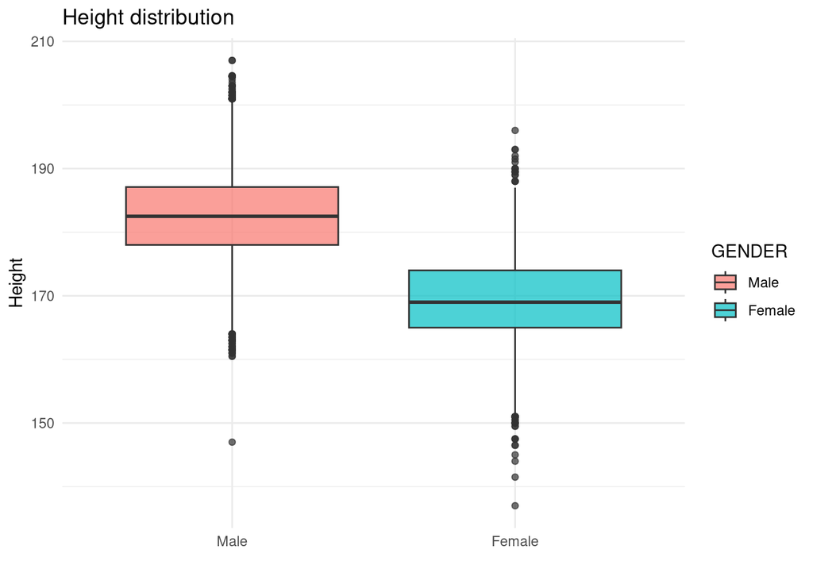

```r
# To make the data in the long format:
#lifelines_long <- lifelines_df %>% pivot_longer(cols = ZIP_CODE)

# Plot it using facet_wrap to see the difference between the genders:
ggplot(data = lifelines_df, mapping = aes( x = GENDER, y = HEIGHT_T1, fill = GENDER)) +
  geom_boxplot( alpha = 0.7) +
  xlab("") +
  ylab("Height") +
#  facet_wrap(~GENDER) +
  ggtitle("Height distribution") +
  theme_minimal()
```

```r
#ggplot(data = lifelines_df, mapping = aes(y =  ))
```

21-11-2024:

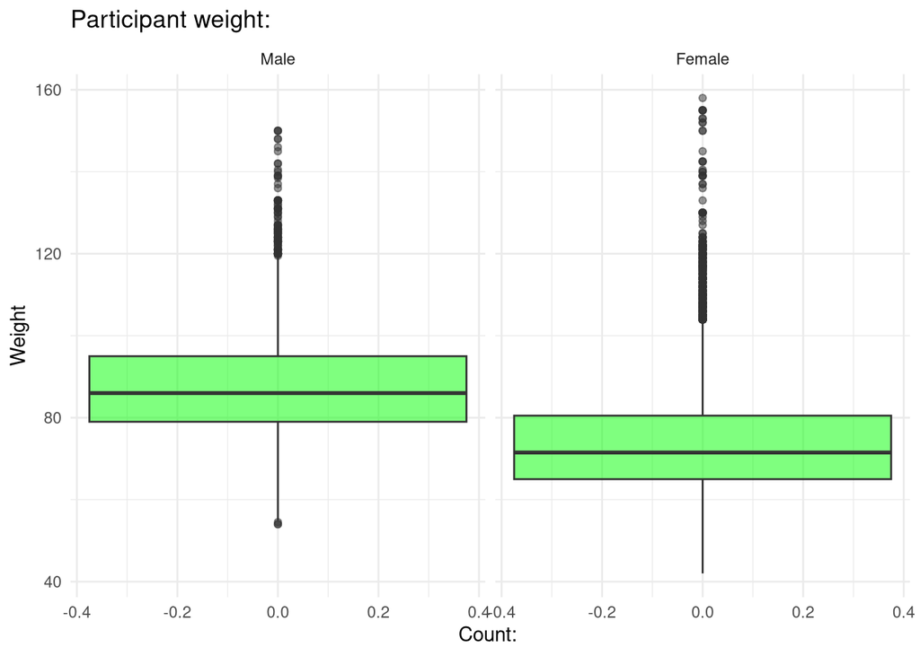

```r
ggplot(data = lifelines_df, mapping = aes(y = WEIGHT_T1) ) +
  geom_boxplot(fill = "green", alpha = 0.5) +
  xlab("Count: ") +
  ylab("Weight") +
  ggtitle("Participant weight:") +
  facet_wrap(~GENDER) +
  theme_minimal()
```

For the woman, the amount of pregnacies was visualized in the following plot:

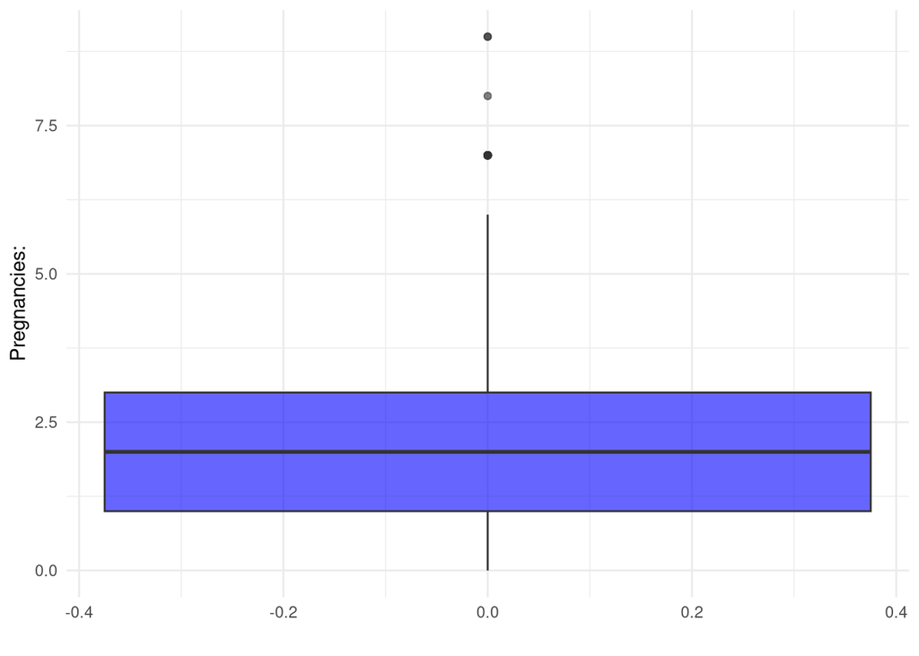

```r
ggplot(data = lifelines_df, mapping = aes(y = PREGNANCIES)) +
  geom_boxplot(fill = "blue", alpha=0.6) +
  xlab("") +
  ylab("Pregnancies:") +
  theme_minimal()
```

```r
ggplot(data = lifelines_df, mapping = aes(y = GENDER) ) +
  geom_bar(fill = "blue", alpha = 0.6) +
  xlab("Count: ") +
  ylab("Gender") +
  ggtitle("Participant count:") +
  theme_minimal()
```

[output not shown]

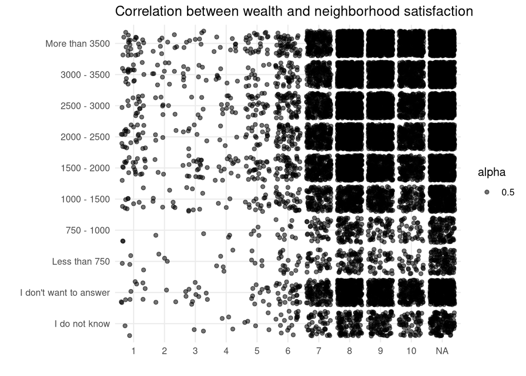

```r
FINANCE <- lifelines_df[!is.na(lifelines_df$FINANCE_T1), ]
#FINANCE <- subset(lifelines_df[FINANCE])

ggplot(data = lifelines_df, mapping = aes(x = neighborhood_satisfaction, y = FINANCE_T1)) +
  geom_jitter(mapping = aes(alpha = 0.5)) +
  xlab("") +
  ylab("") +
  ggtitle("Correlation between wealth and neighborhood satisfaction") +
  theme_minimal()
```

```r
# Balloon plot maken!
```

### 3 Using Generalized linear models to quantify correlations:

Here the variables used are opinion of living arragements as outcome variable and education as predictor. There appears to be a sigificant correlation between these two variables.

```r
neighborhood_prediction <- glm(formula = lifelines_df$NEIGHBOURHOOD1_T2 ~ lifelines_df$EDUCATION_LOWER_T1 + lifelines_df$NEIGHBOURHOOD4_T2, na.action = na.exclude)

neighborhood_prediction_p <- predict(neighborhood_prediction)

summary(neighborhood_prediction)
```

```
##
## Call:
## glm(formula = lifelines_df$NEIGHBOURHOOD1_T2 ~ lifelines_df$EDUCATION_LOWER_T1 +
##     lifelines_df$NEIGHBOURHOOD4_T2, na.action = na.exclude)
##
## Coefficients:
##                                 Estimate Std. Error t value Pr(>|t|)
## (Intercept)                      9.21457    0.02560 359.944  < 2e-16 ***
## lifelines_df$EDUCATION_LOWER_T1 -0.10435    0.02803  -3.723 0.000198 ***
## lifelines_df$NEIGHBOURHOOD4_T2  -0.55102    0.01193 -46.181  < 2e-16 ***
## ---
## Signif. codes:  0 '***' 0.001 '**' 0.01 '*' 0.05 '.' 0.1 ' ' 1
##
## (Dispersion parameter for gaussian family taken to be 1.791762)
##
##     Null deviance: 24769  on 11687  degrees of freedom
## Residual deviance: 20937  on 11685  degrees of freedom
##   (5008 observations deleted due to missingness)
## AIC: 39991
##
## Number of Fisher Scoring iterations: 2
```

According to the glm() prediction above, both education and the wish to move away from their current house are significant predictors for the satisfaction score.  
The latter predictors is obvious, if people want to move away, they are most likely not satisfied with their current place.

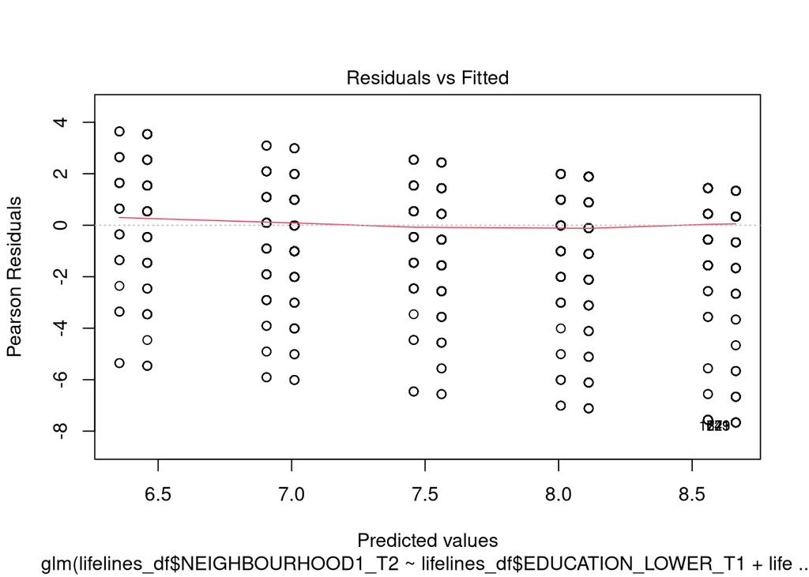

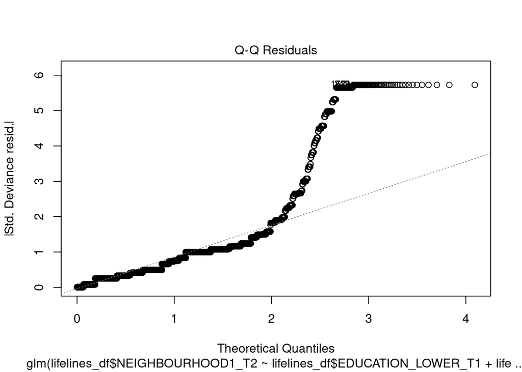

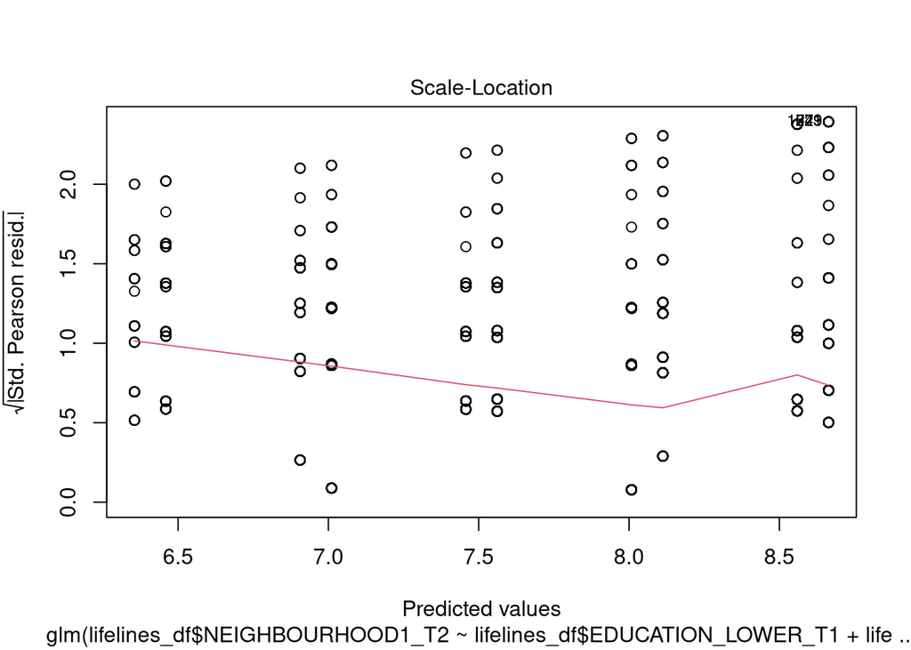

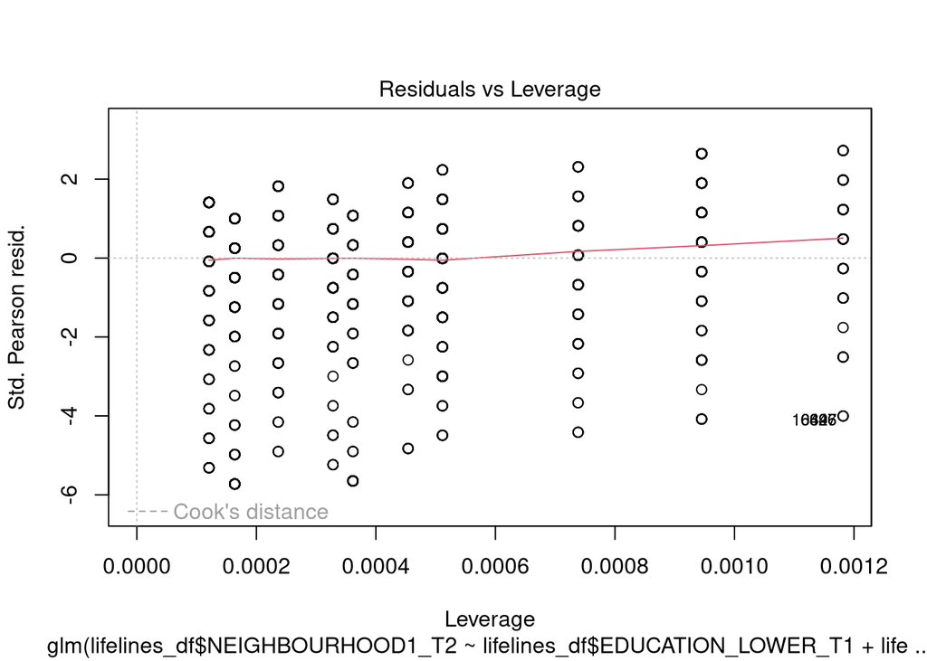

```r
plot(neighborhood_prediction)
```

27-11-2024:

```r
neighborhood <- glm(formula = SMOKING ~ EDUCATION_LOWER_T1, data = lifelines)

predicted <- predict(neighborhood)

summary(neighborhood_prediction)

plot(test2)
```

```r
# Fit the glm model using 'na.exclude'
neighborhood <- glm(formula = SMOKING ~ EDUCATION_LOWER_T1, data = lifelines_df, na.action = na.exclude)

# Get the fitted values and residuals
fitted_values <- neighborhood$fitted.values

# Identify the rows used in fitting the model
used_indices <- !is.na(neighborhood$residuals)  # This identifies which rows were actually used

# Subset both fitted values and smoking data to match these indices
smoking_subset <- lifelines$SMOKING[rownames(lifelines)[used_indices]]

# Now create your dataframe with matching lengths
new_data <- data.frame(fitted_values, smoking_subset)

# Optionally give the columns meaningful names
colnames(new_data) <- c("Fitted_SMOKING", "Actual_SMOKING")
```

### 4 Statistical tests:

First, to check for a normal distribution, I wanted to use the Shapiro-wilk test on the data. The Shapiro-wilk test can only handle up to 5000 observations and given that this Lifelines dataset contains over 16000, this test can not be used. Therefore, the anderson-darling test will be used.

```r
library(nortest)

normality_height <- ad.test(lifelines_df$HEIGHT_T1)
normality_height
```

[output not shown]

```r
test3 <- glm(formula = lifelines$RESPIRATORY_DISEASE_T1 ~ lifelines_df$SMOKING + lifelines_df$LOW_QUALITY_OF_LIFE_T1, na.action = na.exclude)

test2_p <- predict(test3)

summary(test3)
```

```
##
## Call:
## glm(formula = lifelines$RESPIRATORY_DISEASE_T1 ~ lifelines_df$SMOKING +
##     lifelines_df$LOW_QUALITY_OF_LIFE_T1, na.action = na.exclude)
##
## Coefficients:
##                                           Estimate Std. Error t value Pr(>|t|)
## (Intercept)                              7.388e-02  2.404e-03  30.732   <2e-16
## lifelines_df$SMOKINGNon-smoking          2.438e-05  5.659e-03   0.004    0.997
## lifelines_df$LOW_QUALITY_OF_LIFE_T1False 8.087e-02  7.692e-03  10.515   <2e-16
##
## (Intercept)                              ***
## lifelines_df$SMOKINGNon-smoking
## lifelines_df$LOW_QUALITY_OF_LIFE_T1False ***
## ---
## Signif. codes:  0 '***' 0.001 '**' 0.01 '*' 0.05 '.' 0.1 ' ' 1
##
## (Dispersion parameter for gaussian family taken to be 0.0735982)
##
##     Null deviance: 1214.6  on 16394  degrees of freedom
## Residual deviance: 1206.4  on 16392  degrees of freedom
##   (301 observations deleted due to missingness)
## AIC: 3755.2
##
## Number of Fisher Scoring iterations: 2
```

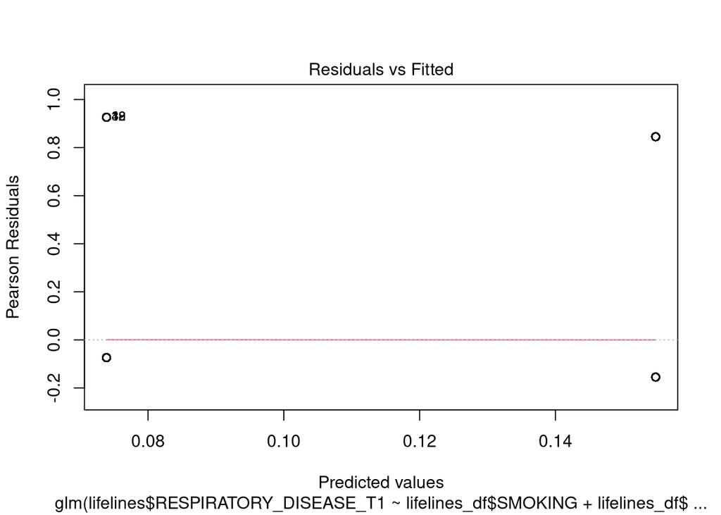

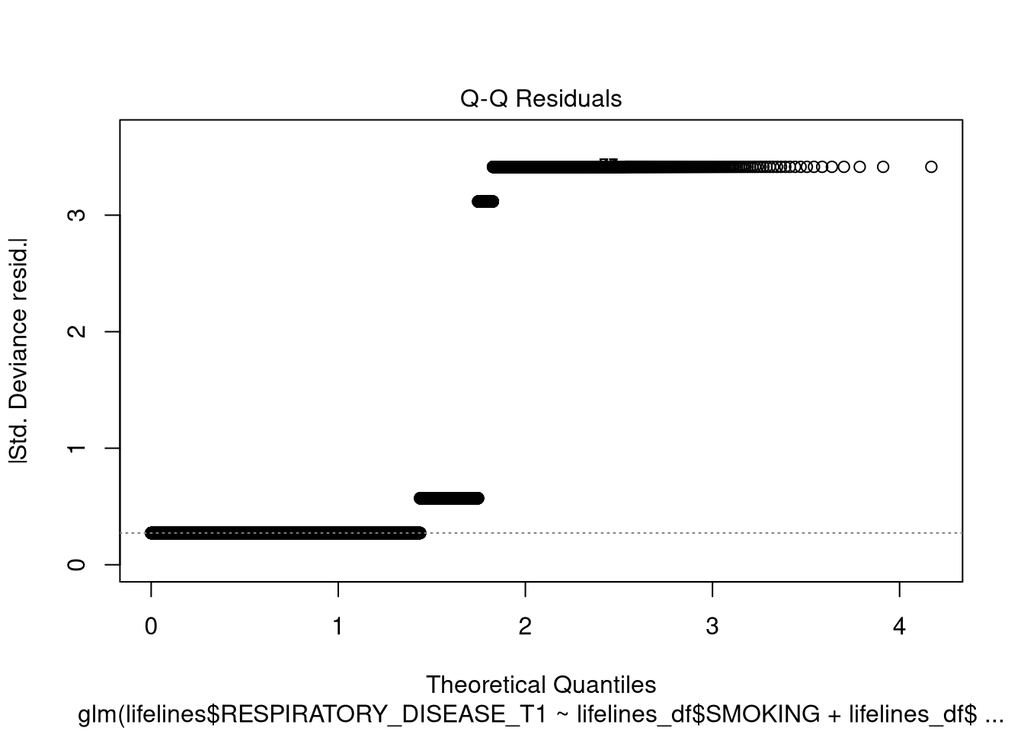

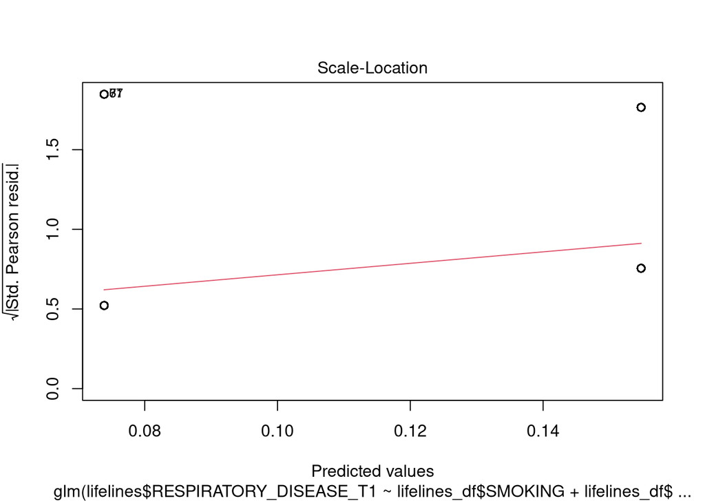

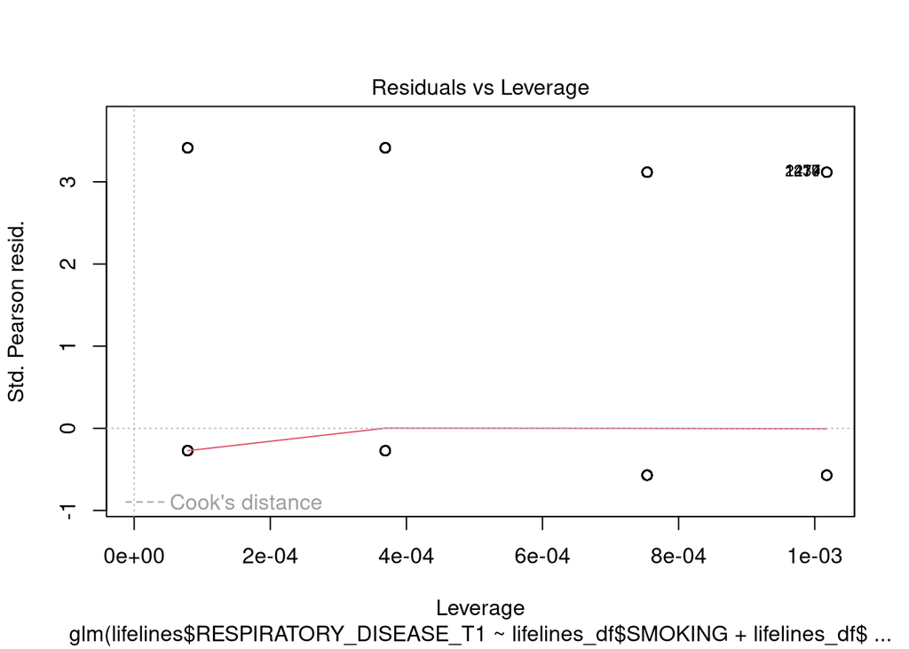

```r
plot(test3)
```

28-11-2024:

```r
lifelines_male <- lifelines_df %>%
  filter(GENDER == "Male")

lifelines_female <- lifelines_df %>%
  filter(GENDER == "Female")

#filter_function <- function(option) {
#  output <- lifelines_df %>%
#    filter(GENDER == fpaste(option))
#
#}

ad_mheight <- ad.test(lifelines_male$HEIGHT_T1)

ad_fheight <- ad.test(lifelines_female$HEIGHT_T1)

ad_mweight <- ad.test(lifelines_male$WEIGHT_T1)

ad_fweight <- ad.test(lifelines_female$WEIGHT_T1)

ad_mbmi <- ad.test(lifelines_male$BMI_T1)

ad_fbmi <- ad.test(lifelines_female$BMI_T1)

p <- c(ad_mheight$p.value, ad_fheight$p.value)
```

```r
t.test(lifelines_female$HEIGHT_T1, lifelines_male$HEIGHT_T1)
```

4-12-2024:

PCA: Below is a principal component analysis to visualize the many dimensions in one 2d plane. The following code does not work yet.

```r
pr <- princomp(t(lifelines_df))

biplot(pr)

d16 <- dist(t(rnaseq[1:6,3:18]))

image(as.matrix(d16))
```

```r
test <- lapply(lifelines_df$AGE_T1, FUN = sum(n)


plot3d( lifelines_df[,1], lifelines_df[,2], lifelines_df[,3], col = lifelines_df$HEIGHT_T1, type = "s", radius = .2 )

play3d( spin3d( axis = c(0, 0, 1), rpm = 20), duration = 10 )
```

```r
height_men <- lifelines_df %>%
  filter(GENDER == "Male")

height_women <- lifelines_df %>%
 filter(GENDER == "Female")


#T-test:
t.test(x = height_men, y = height_women, alternative = "two.sided")
```

```r
# Differences between:
# Men and woman:

# Smoking:
Smoking_MW <- t.test(as.numeric(lifelines_female$SMOKING), as.numeric(lifelines_male$SMOKING))

# Education:
Education_MW <- t.test(as.numeric(lifelines_female$EDUCATION_LOWER_T1), as.numeric(lifelines_male$EDUCATION_LOWER_T1))

# Height:
Height_MW <- t.test(as.numeric(lifelines_female$HEIGHT_T1), as.numeric(lifelines_male$HEIGHT_T1))

# Respiratory disease:
Resp_dis_MW <- t.test(as.numeric(lifelines_female$RESPIRATORY_DISEASE_T1), as.numeric(lifelines_male$RESPIRATORY_DISEASE_T1))

# BMI:
Bmi_MW <- t.test((lifelines_female$BMI_T1), (lifelines_male$BMI_T1))

# Low QOL:
qol_MW <- t.test(as.numeric(lifelines_female$LOW_QUALITY_OF_LIFE_T1), as.numeric(lifelines_male$LOW_QUALITY_OF_LIFE_T1))

# Waist size:
Waist_MW <- t.test(as.numeric(lifelines_female$WAIST_T1), as.numeric(lifelines_male$WAIST_T1))
```

```r
wilcox_test_vector <- c(Smoking_MW[3],Education_MW[3],Height_MW[3],Resp_dis_MW[3],Bmi_MW[3],qol_MW[3],Waist_MW[3])

df_wilcox_gender <- (data.frame((wilcox_test_vector)) %>% rename(
  `Smoking` = p.value,
  `Education` = p.value.1,
  `Height` = p.value.2,
  `Respitoroty dis` = p.value.3,
  `BMI` = p.value.4,
  `Quality of life` = p.value.5,
  `Waist size` = p.value.6
  ))

df_wilcox_gender %>%
  pivot_longer(cols = c(1:7)) -> df_wilcox_gender
```

```r
ggplot(data = df_wilcox_geslacht, mapping = aes(x = name , y = value)) +
  geom_bar(stat = "identity",, fill = "blue", alpha = 0.5) +
  geom_hline(yintercept=0.05, linetype="dashed", color = "red") +
  geom_label_repel(position = position_nudge_repel(y = -0.07),aes(label = round(value,digits = 3)) ) +
  ylab("P-value:") +
  xlab(" ") +
  theme_minimal() +
  theme(axis.text.x = element_text(angle = 90, vjust = 0.6))
```

[output not shown]

3-01-2025: The next step is to make a package from the project to make it easy to install via install_github().

11-01-2025:

```r
library(forcats)
library(hrbrthemes)
library(viridis)
```

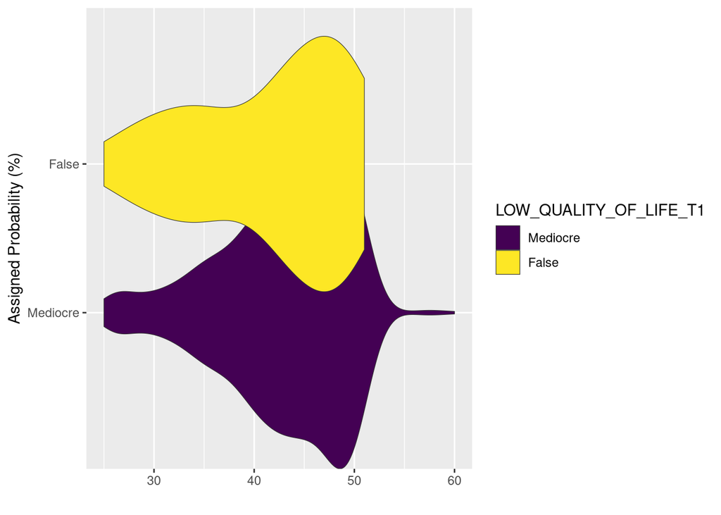

```r
violin_df <- na.omit(lifelines_df)


ggplot(data = violin_df, aes(x= AGE_T1, y= LOW_QUALITY_OF_LIFE_T1, fill=LOW_QUALITY_OF_LIFE_T1)) +
    geom_violin(width=2.1, size=0.2) +
    scale_fill_viridis(discrete=TRUE) +
    scale_color_viridis(discrete=TRUE) +
    xlab("") +
    ylab("Assigned Probability (%)")
```

As seen in the graph above, there is a steep cut-off after 50 years.